# The Crown report

Yuliya Martyniuk

2026-04-16

# The Crown ( TV series)

## Description

*The Crown* is a historical drama television series about the reign of Queen Elizabeth II, created and principally written by Peter Morgan and produced by Left Bank Pictures and Sony Pictures Television for Netflix. Morgan developed the series from his film The Queen (2006) and his stage play The Audience (2013), which also focused on Elizabeth.

[figure not shown]

## Rating statistics

Summary Statistics for The Crown Episode Ratings

| Statistic | Score |
| --- | --- |
| Mean Rating | 8.26 |
| Median Rating | 8.30 |
| Highest Rating | 9.30 |
| Lowest Rating | 7.20 |

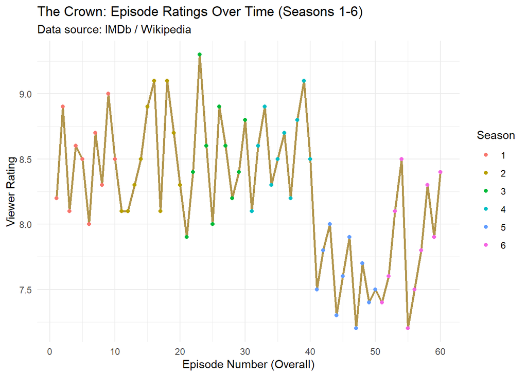

A noticeable shift occurs at Episode 41 (the start of Season 5), where the ratings enter a “lower tier” than previous years. Specifically, the average rating decreased by 0.92 points between Season 3 (avg 8.51) and Season 5 (avg 7.59). While Season 6 shows some recovery toward the series finale, the ratings remain lower than the early “Golden Era” of the show.

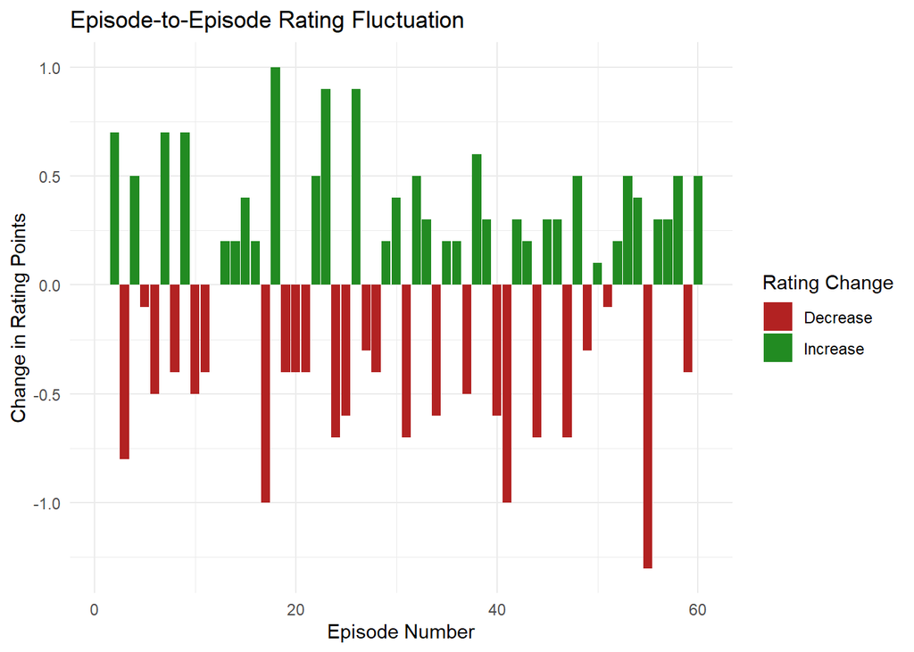

The fluctuation bar chart tracks the “momentum” of the show by measuring the change in rating from one episode to the next. The graph reveals that The Crown is a highly volatile show, often following a “dip and recovery” pattern.

- **Largest Increase**: The most significant positive jump occurred in Season 2, where the rating increased by 1.0 point between Episode 17 and Episode 18 (“Dear Mrs. Kennedy”).
- **Largest Decrease**: The sharpest decline in momentum happened in Season 6, where the rating decreased by 1.3 points between Episode 54 and Episode 55, marking the transition between the two volumes of the final season.